# Risk Factor Analysis

## Outcome Variable

**Outcome Variable:** sstunted

## Predictor Variables

**Intervention Variable:** enwast

**Adjustment Set:**

unadjusted

## Stratifying Variables

The analysis was stratified on these variable(s):

- agecat
- studyid
- country

## Data Summary

| agecat | studyid | country | enwast | sstunted | n_cell | n |
| --- | --- | --- | --- | --- | --- | --- |
| Birth | CMC-V-BCS-2002 | INDIA | 0 | 0 | 75 | 87 |
| Birth | CMC-V-BCS-2002 | INDIA | 0 | 1 | 0 | 87 |
| Birth | CMC-V-BCS-2002 | INDIA | 1 | 0 | 11 | 87 |
| Birth | CMC-V-BCS-2002 | INDIA | 1 | 1 | 1 | 87 |
| Birth | CMIN | BANGLADESH | 0 | 0 | 15 | 19 |
| Birth | CMIN | BANGLADESH | 0 | 1 | 0 | 19 |
| Birth | CMIN | BANGLADESH | 1 | 0 | 4 | 19 |
| Birth | CMIN | BANGLADESH | 1 | 1 | 0 | 19 |
| Birth | COHORTS | GUATEMALA | 0 | 0 | 564 | 762 |
| Birth | COHORTS | GUATEMALA | 0 | 1 | 0 | 762 |
| Birth | COHORTS | GUATEMALA | 1 | 0 | 198 | 762 |
| Birth | COHORTS | GUATEMALA | 1 | 1 | 0 | 762 |
| Birth | COHORTS | INDIA | 0 | 0 | 5097 | 6231 |
| Birth | COHORTS | INDIA | 0 | 1 | 0 | 6231 |
| Birth | COHORTS | INDIA | 1 | 0 | 1134 | 6231 |
| Birth | COHORTS | INDIA | 1 | 1 | 0 | 6231 |
| Birth | COHORTS | PHILIPPINES | 0 | 0 | 2448 | 2910 |
| Birth | COHORTS | PHILIPPINES | 0 | 1 | 0 | 2910 |
| Birth | COHORTS | PHILIPPINES | 1 | 0 | 462 | 2910 |
| Birth | COHORTS | PHILIPPINES | 1 | 1 | 0 | 2910 |
| Birth | CONTENT | PERU | 0 | 0 | 2 | 2 |
| Birth | CONTENT | PERU | 0 | 1 | 0 | 2 |
| Birth | CONTENT | PERU | 1 | 0 | 0 | 2 |
| Birth | CONTENT | PERU | 1 | 1 | 0 | 2 |
| Birth | EE | PAKISTAN | 0 | 0 | 154 | 180 |
| Birth | EE | PAKISTAN | 0 | 1 | 1 | 180 |
| Birth | EE | PAKISTAN | 1 | 0 | 25 | 180 |
| Birth | EE | PAKISTAN | 1 | 1 | 0 | 180 |
| Birth | GMS-Nepal | NEPAL | 0 | 0 | 509 | 645 |
| Birth | GMS-Nepal | NEPAL | 0 | 1 | 0 | 645 |

[output cut: 298 more lines]

The following strata were considered:

- agecat: 24 months, studyid: CMC-V-BCS-2002, country: INDIA
- agecat: 24 months, studyid: CMIN, country: BANGLADESH
- agecat: 24 months, studyid: COHORTS, country: GUATEMALA
- agecat: 24 months, studyid: COHORTS, country: INDIA
- agecat: 24 months, studyid: COHORTS, country: PHILIPPINES
- agecat: 24 months, studyid: CONTENT, country: PERU
- agecat: 24 months, studyid: EE, country: PAKISTAN
- agecat: 24 months, studyid: GMS-Nepal, country: NEPAL
- agecat: 24 months, studyid: IRC, country: INDIA
- agecat: 24 months, studyid: JiVitA-3, country: BANGLADESH
- agecat: 24 months, studyid: JiVitA-4, country: BANGLADESH
- agecat: 24 months, studyid: Keneba, country: GAMBIA
- agecat: 24 months, studyid: LCNI-5, country: MALAWI
- agecat: 24 months, studyid: MAL-ED, country: BANGLADESH
- agecat: 24 months, studyid: MAL-ED, country: BRAZIL
- agecat: 24 months, studyid: MAL-ED, country: INDIA
- agecat: 24 months, studyid: MAL-ED, country: NEPAL
- agecat: 24 months, studyid: MAL-ED, country: PERU
- agecat: 24 months, studyid: MAL-ED, country: SOUTH AFRICA
- agecat: 24 months, studyid: MAL-ED, country: TANZANIA, UNITED REPUBLIC OF
- agecat: 24 months, studyid: NIH-Birth, country: BANGLADESH
- agecat: 24 months, studyid: NIH-Crypto, country: BANGLADESH
- agecat: 24 months, studyid: PROBIT, country: BELARUS
- agecat: 24 months, studyid: PROVIDE, country: BANGLADESH
- agecat: 24 months, studyid: TanzaniaChild2, country: TANZANIA, UNITED REPUBLIC OF
- agecat: 24 months, studyid: ZVITAMBO, country: ZIMBABWE
- agecat: 6 months, studyid: CMC-V-BCS-2002, country: INDIA
- agecat: 6 months, studyid: CMIN, country: BANGLADESH
- agecat: 6 months, studyid: COHORTS, country: GUATEMALA
- agecat: 6 months, studyid: COHORTS, country: INDIA
- agecat: 6 months, studyid: COHORTS, country: PHILIPPINES
- agecat: 6 months, studyid: CONTENT, country: PERU
- agecat: 6 months, studyid: EE, country: PAKISTAN
- agecat: 6 months, studyid: GMS-Nepal, country: NEPAL
- agecat: 6 months, studyid: Guatemala BSC, country: GUATEMALA
- agecat: 6 months, studyid: IRC, country: INDIA
- agecat: 6 months, studyid: JiVitA-3, country: BANGLADESH
- agecat: 6 months, studyid: JiVitA-4, country: BANGLADESH
- agecat: 6 months, studyid: Keneba, country: GAMBIA
- agecat: 6 months, studyid: LCNI-5, country: MALAWI
- agecat: 6 months, studyid: MAL-ED, country: BANGLADESH
- agecat: 6 months, studyid: MAL-ED, country: BRAZIL
- agecat: 6 months, studyid: MAL-ED, country: INDIA
- agecat: 6 months, studyid: MAL-ED, country: NEPAL
- agecat: 6 months, studyid: MAL-ED, country: PERU
- agecat: 6 months, studyid: MAL-ED, country: SOUTH AFRICA
- agecat: 6 months, studyid: MAL-ED, country: TANZANIA, UNITED REPUBLIC OF
- agecat: 6 months, studyid: NIH-Birth, country: BANGLADESH
- agecat: 6 months, studyid: NIH-Crypto, country: BANGLADESH
- agecat: 6 months, studyid: PROBIT, country: BELARUS
- agecat: 6 months, studyid: PROVIDE, country: BANGLADESH
- agecat: 6 months, studyid: ResPak, country: PAKISTAN
- agecat: 6 months, studyid: SAS-CompFeed, country: INDIA
- agecat: 6 months, studyid: SAS-FoodSuppl, country: INDIA
- agecat: 6 months, studyid: TanzaniaChild2, country: TANZANIA, UNITED REPUBLIC OF
- agecat: 6 months, studyid: ZVITAMBO, country: ZIMBABWE
- agecat: Birth, studyid: CMC-V-BCS-2002, country: INDIA
- agecat: Birth, studyid: CMIN, country: BANGLADESH
- agecat: Birth, studyid: COHORTS, country: GUATEMALA
- agecat: Birth, studyid: COHORTS, country: INDIA
- agecat: Birth, studyid: COHORTS, country: PHILIPPINES
- agecat: Birth, studyid: CONTENT, country: PERU
- agecat: Birth, studyid: EE, country: PAKISTAN
- agecat: Birth, studyid: GMS-Nepal, country: NEPAL
- agecat: Birth, studyid: IRC, country: INDIA
- agecat: Birth, studyid: JiVitA-3, country: BANGLADESH
- agecat: Birth, studyid: JiVitA-4, country: BANGLADESH
- agecat: Birth, studyid: Keneba, country: GAMBIA
- agecat: Birth, studyid: MAL-ED, country: BANGLADESH
- agecat: Birth, studyid: MAL-ED, country: BRAZIL
- agecat: Birth, studyid: MAL-ED, country: INDIA
- agecat: Birth, studyid: MAL-ED, country: NEPAL
- agecat: Birth, studyid: MAL-ED, country: PERU
- agecat: Birth, studyid: MAL-ED, country: SOUTH AFRICA
- agecat: Birth, studyid: MAL-ED, country: TANZANIA, UNITED REPUBLIC OF
- agecat: Birth, studyid: NIH-Birth, country: BANGLADESH
- agecat: Birth, studyid: NIH-Crypto, country: BANGLADESH
- agecat: Birth, studyid: PROBIT, country: BELARUS
- agecat: Birth, studyid: PROVIDE, country: BANGLADESH
- agecat: Birth, studyid: ResPak, country: PAKISTAN
- agecat: Birth, studyid: SAS-CompFeed, country: INDIA
- agecat: Birth, studyid: ZVITAMBO, country: ZIMBABWE

### Dropped Strata

Some strata were dropped due to rare outcomes:

- agecat: Birth, studyid: CMC-V-BCS-2002, country: INDIA
- agecat: Birth, studyid: CMIN, country: BANGLADESH
- agecat: Birth, studyid: COHORTS, country: GUATEMALA
- agecat: Birth, studyid: COHORTS, country: INDIA
- agecat: Birth, studyid: COHORTS, country: PHILIPPINES
- agecat: Birth, studyid: CONTENT, country: PERU
- agecat: Birth, studyid: EE, country: PAKISTAN
- agecat: Birth, studyid: GMS-Nepal, country: NEPAL
- agecat: Birth, studyid: IRC, country: INDIA
- agecat: Birth, studyid: JiVitA-3, country: BANGLADESH
- agecat: Birth, studyid: JiVitA-4, country: BANGLADESH
- agecat: Birth, studyid: Keneba, country: GAMBIA
- agecat: Birth, studyid: MAL-ED, country: BANGLADESH
- agecat: Birth, studyid: MAL-ED, country: BRAZIL
- agecat: Birth, studyid: MAL-ED, country: INDIA
- agecat: Birth, studyid: MAL-ED, country: NEPAL
- agecat: Birth, studyid: MAL-ED, country: PERU
- agecat: Birth, studyid: MAL-ED, country: SOUTH AFRICA
- agecat: Birth, studyid: MAL-ED, country: TANZANIA, UNITED REPUBLIC OF
- agecat: Birth, studyid: NIH-Birth, country: BANGLADESH
- agecat: Birth, studyid: NIH-Crypto, country: BANGLADESH
- agecat: Birth, studyid: PROBIT, country: BELARUS
- agecat: Birth, studyid: PROVIDE, country: BANGLADESH
- agecat: Birth, studyid: ResPak, country: PAKISTAN
- agecat: Birth, studyid: SAS-CompFeed, country: INDIA
- agecat: Birth, studyid: ZVITAMBO, country: ZIMBABWE
- agecat: 6 months, studyid: CMIN, country: BANGLADESH
- agecat: 6 months, studyid: CONTENT, country: PERU
- agecat: 6 months, studyid: GMS-Nepal, country: NEPAL
- agecat: 6 months, studyid: Guatemala BSC, country: GUATEMALA
- agecat: 6 months, studyid: MAL-ED, country: BANGLADESH
- agecat: 6 months, studyid: MAL-ED, country: BRAZIL
- agecat: 6 months, studyid: MAL-ED, country: INDIA
- agecat: 6 months, studyid: MAL-ED, country: NEPAL
- agecat: 6 months, studyid: MAL-ED, country: PERU
- agecat: 6 months, studyid: MAL-ED, country: SOUTH AFRICA
- agecat: 6 months, studyid: MAL-ED, country: TANZANIA, UNITED REPUBLIC OF
- agecat: 6 months, studyid: TanzaniaChild2, country: TANZANIA, UNITED REPUBLIC OF
- agecat: 24 months, studyid: CONTENT, country: PERU
- agecat: 24 months, studyid: LCNI-5, country: MALAWI
- agecat: 24 months, studyid: MAL-ED, country: BRAZIL
- agecat: 24 months, studyid: MAL-ED, country: NEPAL
- agecat: 24 months, studyid: MAL-ED, country: PERU
- agecat: 24 months, studyid: MAL-ED, country: SOUTH AFRICA
- agecat: 24 months, studyid: MAL-ED, country: TANZANIA, UNITED REPUBLIC OF
- agecat: 24 months, studyid: TanzaniaChild2, country: TANZANIA, UNITED REPUBLIC OF

## Methods Detail

We’re interested in the causal parameters $E[Y_a]$ for all values of $a \in \mathcal{A}$. These parameters represent the mean outcome if, possibly contrary to fact, we intervened to set all units to have $A=a$. Under the randomization and positivity assumptions, these are identified by the statistical parameters $\psi_a=E_W[E_{Y|A,W}(Y|A=a,W)]$. In addition, we’re interested in the mean of $Y$, $E[Y]$ under no intervention (the observed mean). We will estimate these parameters by using SuperLearner to fit the relevant likelihood factors – $E_{Y|A,W}(Y|A=a,W)$ and $p(A=a|W)$, and then updating our likelihood fit using a joint TMLE.

For unadjusted analyses ($W=\{\}$), initial likelihoods were estimated using Lrnr_glm to estimate the simple $E(Y|A)$ and Lrnr_mean to estimate $p(A)$. For adjusted analyses, a small library containing Lrnr_glmnet, Lrnr_xgboost, and Lrnr_mean was used.

Having estimated these parameters, we will then use the delta method to estimate relative risks and attributable risks relative to a prespecified baseline level of $A$.

# Results Detail

## Results Plots

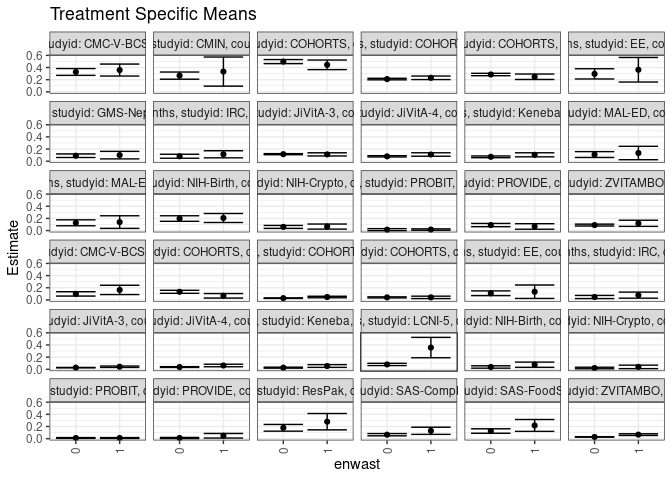

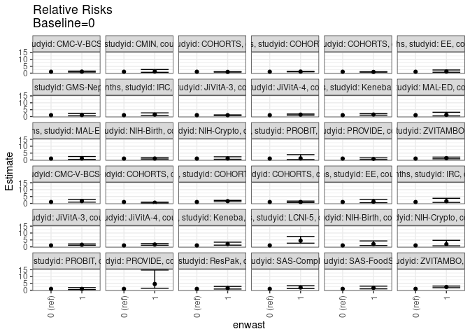

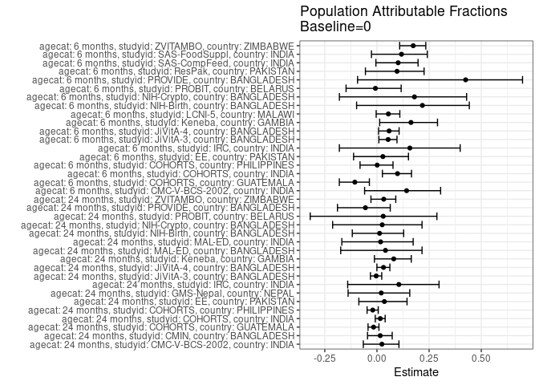

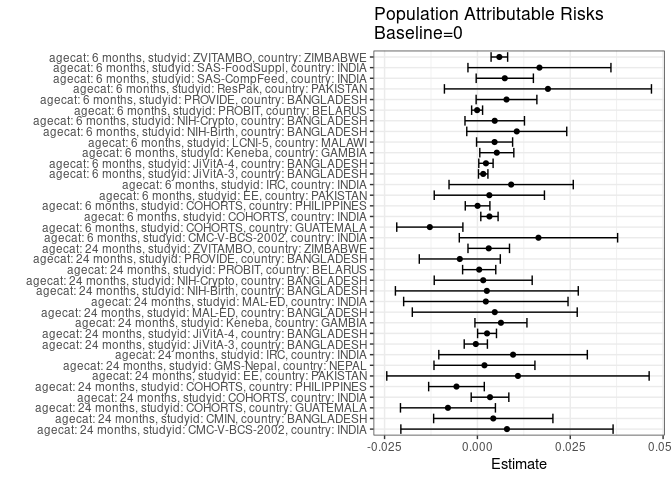

## Results Table

### Parameter: TSM

| agecat | studyid | country | intervention_level | baseline_level | estimate | ci_lower | ci_upper |
| --- | --- | --- | --- | --- | --- | --- | --- |
| 6 months | CMC-V-BCS-2002 | INDIA | 0 | NA | 0.0992647 | 0.0636804 | 0.1348490 |
| 6 months | CMC-V-BCS-2002 | INDIA | 1 | NA | 0.1648352 | 0.0884977 | 0.2411726 |
| 6 months | COHORTS | GUATEMALA | 0 | NA | 0.1337931 | 0.1089990 | 0.1585872 |
| 6 months | COHORTS | GUATEMALA | 1 | NA | 0.0681818 | 0.0309227 | 0.1054410 |
| 6 months | COHORTS | INDIA | 0 | NA | 0.0296421 | 0.0251031 | 0.0341810 |
| 6 months | COHORTS | INDIA | 1 | NA | 0.0480769 | 0.0356793 | 0.0604745 |
| 6 months | COHORTS | PHILIPPINES | 0 | NA | 0.0419900 | 0.0335902 | 0.0503897 |
| 6 months | COHORTS | PHILIPPINES | 1 | NA | 0.0422886 | 0.0226121 | 0.0619650 |
| 6 months | EE | PAKISTAN | 0 | NA | 0.1098039 | 0.0713647 | 0.1482432 |
| 6 months | EE | PAKISTAN | 1 | NA | 0.1351351 | 0.0247907 | 0.2454796 |
| 6 months | IRC | INDIA | 0 | NA | 0.0485075 | 0.0227527 | 0.0742622 |
| 6 months | IRC | INDIA | 1 | NA | 0.0789474 | 0.0293823 | 0.1285125 |
| 6 months | JiVitA-3 | BANGLADESH | 0 | NA | 0.0275071 | 0.0244343 | 0.0305799 |
| 6 months | JiVitA-3 | BANGLADESH | 1 | NA | 0.0421053 | 0.0307490 | 0.0534615 |
| 6 months | JiVitA-4 | BANGLADESH | 0 | NA | 0.0371571 | 0.0311868 | 0.0431274 |
| 6 months | JiVitA-4 | BANGLADESH | 1 | NA | 0.0625000 | 0.0417916 | 0.0832084 |
| 6 months | Keneba | GAMBIA | 0 | NA | 0.0268129 | 0.0189954 | 0.0346305 |
| 6 months | Keneba | GAMBIA | 1 | NA | 0.0541237 | 0.0316047 | 0.0766428 |
| 6 months | LCNI-5 | MALAWI | 0 | NA | 0.0800000 | 0.0613187 | 0.0986813 |
| 6 months | LCNI-5 | MALAWI | 1 | NA | 0.3571429 | 0.1895146 | 0.5247712 |
| 6 months | NIH-Birth | BANGLADESH | 0 | NA | 0.0380435 | 0.0184792 | 0.0576078 |
| 6 months | NIH-Birth | BANGLADESH | 1 | NA | 0.0753425 | 0.0324871 | 0.1181978 |
| 6 months | NIH-Crypto | BANGLADESH | 0 | NA | 0.0212766 | 0.0088287 | 0.0337245 |
| 6 months | NIH-Crypto | BANGLADESH | 1 | NA | 0.0395480 | 0.0108154 | 0.0682806 |
| 6 months | PROBIT | BELARUS | 0 | NA | 0.0111908 | 0.0049241 | 0.0174575 |
| 6 months | PROBIT | BELARUS | 1 | NA | 0.0107702 | 0.0038657 | 0.0176748 |
| 6 months | PROVIDE | BANGLADESH | 0 | NA | 0.0105932 | 0.0013496 | 0.0198369 |
| 6 months | PROVIDE | BANGLADESH | 1 | NA | 0.0480000 | 0.0104944 | 0.0855056 |
| 6 months | ResPak | PAKISTAN | 0 | NA | 0.1783784 | 0.1230913 | 0.2336655 |
| 6 months | ResPak | PAKISTAN | 1 | NA | 0.2790698 | 0.1447093 | 0.4134302 |
| 6 months | SAS-CompFeed | INDIA | 0 | NA | 0.0651769 | 0.0463612 | 0.0839926 |
| 6 months | SAS-CompFeed | INDIA | 1 | NA | 0.1294964 | 0.0704696 | 0.1885232 |
| 6 months | SAS-FoodSuppl | INDIA | 0 | NA | 0.1254019 | 0.0885469 | 0.1622569 |
| 6 months | SAS-FoodSuppl | INDIA | 1 | NA | 0.2173913 | 0.1199397 | 0.3148429 |
| 6 months | ZVITAMBO | ZIMBABWE | 0 | NA | 0.0280997 | 0.0242013 | 0.0319980 |
| 6 months | ZVITAMBO | ZIMBABWE | 1 | NA | 0.0661417 | 0.0524723 | 0.0798112 |
| 24 months | CMC-V-BCS-2002 | INDIA | 0 | NA | 0.3272059 | 0.2713701 | 0.3830417 |
| 24 months | CMC-V-BCS-2002 | INDIA | 1 | NA | 0.3586957 | 0.2605555 | 0.4568358 |
| 24 months | CMIN | BANGLADESH | 0 | NA | 0.2672811 | 0.2082734 | 0.3262889 |
| 24 months | CMIN | BANGLADESH | 1 | NA | 0.3333333 | 0.0942583 | 0.5724084 |
| 24 months | COHORTS | GUATEMALA | 0 | NA | 0.4977117 | 0.4645475 | 0.5308759 |
| 24 months | COHORTS | GUATEMALA | 1 | NA | 0.4444444 | 0.3656698 | 0.5232191 |
| 24 months | COHORTS | INDIA | 0 | NA | 0.2100188 | 0.1977746 | 0.2222631 |
| 24 months | COHORTS | INDIA | 1 | NA | 0.2310513 | 0.2021634 | 0.2599393 |
| 24 months | COHORTS | PHILIPPINES | 0 | NA | 0.2855706 | 0.2657161 | 0.3054252 |
| 24 months | COHORTS | PHILIPPINES | 1 | NA | 0.2486034 | 0.2038230 | 0.2933837 |
| 24 months | EE | PAKISTAN | 0 | NA | 0.2956522 | 0.2119428 | 0.3793616 |
| 24 months | EE | PAKISTAN | 1 | NA | 0.3636364 | 0.1618862 | 0.5653865 |
| 24 months | GMS-Nepal | NEPAL | 0 | NA | 0.0904110 | 0.0609591 | 0.1198628 |
| 24 months | GMS-Nepal | NEPAL | 1 | NA | 0.1000000 | 0.0379523 | 0.1620477 |
| 24 months | IRC | INDIA | 0 | NA | 0.0817844 | 0.0489940 | 0.1145748 |
| 24 months | IRC | INDIA | 1 | NA | 0.1140351 | 0.0556111 | 0.1724590 |
| 24 months | JiVitA-3 | BANGLADESH | 0 | NA | 0.1160075 | 0.1070437 | 0.1249713 |
| 24 months | JiVitA-3 | BANGLADESH | 1 | NA | 0.1121951 | 0.0860994 | 0.1382909 |
| 24 months | JiVitA-4 | BANGLADESH | 0 | NA | 0.0801420 | 0.0701936 | 0.0900905 |
| 24 months | JiVitA-4 | BANGLADESH | 1 | NA | 0.1102151 | 0.0816854 | 0.1387447 |
| 24 months | Keneba | GAMBIA | 0 | NA | 0.0723781 | 0.0585725 | 0.0861838 |
| 24 months | Keneba | GAMBIA | 1 | NA | 0.1052632 | 0.0717849 | 0.1387414 |
| 24 months | MAL-ED | BANGLADESH | 0 | NA | 0.1097561 | 0.0617962 | 0.1577160 |
| 24 months | MAL-ED | BANGLADESH | 1 | NA | 0.1351351 | 0.0247048 | 0.2455655 |
| 24 months | MAL-ED | INDIA | 0 | NA | 0.1277778 | 0.0788980 | 0.1766575 |
| 24 months | MAL-ED | INDIA | 1 | NA | 0.1395349 | 0.0357348 | 0.2433350 |
| 24 months | NIH-Birth | BANGLADESH | 0 | NA | 0.1979522 | 0.1522722 | 0.2436322 |
| 24 months | NIH-Birth | BANGLADESH | 1 | NA | 0.2068966 | 0.1330905 | 0.2807026 |
| 24 months | NIH-Crypto | BANGLADESH | 0 | NA | 0.0604396 | 0.0359345 | 0.0849446 |
| 24 months | NIH-Crypto | BANGLADESH | 1 | NA | 0.0661765 | 0.0243552 | 0.1079978 |
| 24 months | PROBIT | BELARUS | 0 | NA | 0.0153945 | -0.0010323 | 0.0318213 |
| 24 months | PROBIT | BELARUS | 1 | NA | 0.0175055 | 0.0061504 | 0.0288605 |
| 24 months | PROVIDE | BANGLADESH | 0 | NA | 0.0907080 | 0.0642087 | 0.1172073 |
| 24 months | PROVIDE | BANGLADESH | 1 | NA | 0.0677966 | 0.0223975 | 0.1131958 |
| 24 months | ZVITAMBO | ZIMBABWE | 0 | NA | 0.0906389 | 0.0752965 | 0.1059814 |
| 24 months | ZVITAMBO | ZIMBABWE | 1 | NA | 0.1194969 | 0.0690612 | 0.1699325 |

### Parameter: E(Y)

| agecat | studyid | country | intervention_level | baseline_level | estimate | ci_lower | ci_upper |
| --- | --- | --- | --- | --- | --- | --- | --- |
| 6 months | CMC-V-BCS-2002 | INDIA | NA | NA | 0.1157025 | 0.0827518 | 0.1486532 |
| 6 months | COHORTS | GUATEMALA | NA | NA | 0.1209767 | 0.0996719 | 0.1422815 |
| 6 months | COHORTS | INDIA | NA | NA | 0.0328826 | 0.0285497 | 0.0372155 |
| 6 months | COHORTS | PHILIPPINES | NA | NA | 0.0420363 | 0.0343109 | 0.0497616 |
| 6 months | EE | PAKISTAN | NA | NA | 0.1130137 | 0.0766368 | 0.1493906 |
| 6 months | IRC | INDIA | NA | NA | 0.0575916 | 0.0341987 | 0.0809846 |
| 6 months | JiVitA-3 | BANGLADESH | NA | NA | 0.0290649 | 0.0261073 | 0.0320225 |
| 6 months | JiVitA-4 | BANGLADESH | NA | NA | 0.0394558 | 0.0337069 | 0.0452047 |
| 6 months | Keneba | GAMBIA | NA | NA | 0.0320355 | 0.0243714 | 0.0396996 |
| 6 months | LCNI-5 | MALAWI | NA | NA | 0.0846246 | 0.0657805 | 0.1034686 |
| 6 months | NIH-Birth | BANGLADESH | NA | NA | 0.0486381 | 0.0300237 | 0.0672526 |
| 6 months | NIH-Crypto | BANGLADESH | NA | NA | 0.0259366 | 0.0141026 | 0.0377706 |
| 6 months | PROBIT | BELARUS | NA | NA | 0.0111090 | 0.0054740 | 0.0167440 |
| 6 months | PROVIDE | BANGLADESH | NA | NA | 0.0184255 | 0.0076286 | 0.0292223 |
| 6 months | ResPak | PAKISTAN | NA | NA | 0.1973684 | 0.1455920 | 0.2491449 |
| 6 months | SAS-CompFeed | INDIA | NA | NA | 0.0725474 | 0.0527677 | 0.0923271 |
| 6 months | SAS-FoodSuppl | INDIA | NA | NA | 0.1421053 | 0.1069532 | 0.1772573 |
| 6 months | ZVITAMBO | ZIMBABWE | NA | NA | 0.0340103 | 0.0300807 | 0.0379399 |
| 24 months | CMC-V-BCS-2002 | INDIA | NA | NA | 0.3351648 | 0.2866046 | 0.3837251 |
| 24 months | CMIN | BANGLADESH | NA | NA | 0.2715517 | 0.2141972 | 0.3289063 |
| 24 months | COHORTS | GUATEMALA | NA | NA | 0.4897760 | 0.4591879 | 0.5203642 |
| 24 months | COHORTS | INDIA | NA | NA | 0.2134122 | 0.2021332 | 0.2246912 |
| 24 months | COHORTS | PHILIPPINES | NA | NA | 0.2799318 | 0.2617642 | 0.2980994 |
| 24 months | EE | PAKISTAN | NA | NA | 0.3065693 | 0.2290795 | 0.3840591 |
| 24 months | GMS-Nepal | NEPAL | NA | NA | 0.0923077 | 0.0656815 | 0.1189338 |
| 24 months | IRC | INDIA | NA | NA | 0.0913838 | 0.0624876 | 0.1202800 |
| 24 months | JiVitA-3 | BANGLADESH | NA | NA | 0.1155758 | 0.1070958 | 0.1240558 |
| 24 months | JiVitA-4 | BANGLADESH | NA | NA | 0.0827346 | 0.0732177 | 0.0922516 |
| 24 months | Keneba | GAMBIA | NA | NA | 0.0787120 | 0.0658197 | 0.0916043 |
| 24 months | MAL-ED | BANGLADESH | NA | NA | 0.1144279 | 0.0703104 | 0.1585454 |
| 24 months | MAL-ED | INDIA | NA | NA | 0.1300448 | 0.0857996 | 0.1742901 |
| 24 months | NIH-Birth | BANGLADESH | NA | NA | 0.2004890 | 0.1616404 | 0.2393376 |
| 24 months | NIH-Crypto | BANGLADESH | NA | NA | 0.0620000 | 0.0408410 | 0.0831590 |
| 24 months | PROBIT | BELARUS | NA | NA | 0.0158730 | 0.0028238 | 0.0289223 |
| 24 months | PROVIDE | BANGLADESH | NA | NA | 0.0859649 | 0.0629328 | 0.1089970 |
| 24 months | ZVITAMBO | ZIMBABWE | NA | NA | 0.0936877 | 0.0789610 | 0.1084144 |

### Parameter: RR

| agecat | studyid | country | intervention_level | baseline_level | estimate | ci_lower | ci_upper |
| --- | --- | --- | --- | --- | --- | --- | --- |
| 6 months | CMC-V-BCS-2002 | INDIA | 0 | 0 | 1.0000000 | 1.0000000 | 1.0000000 |
| 6 months | CMC-V-BCS-2002 | INDIA | 1 | 0 | 1.6605617 | 0.9245110 | 2.9826201 |
| 6 months | COHORTS | GUATEMALA | 0 | 0 | 1.0000000 | 1.0000000 | 1.0000000 |
| 6 months | COHORTS | GUATEMALA | 1 | 0 | 0.5096064 | 0.2861752 | 0.9074814 |
| 6 months | COHORTS | INDIA | 0 | 0 | 1.0000000 | 1.0000000 | 1.0000000 |
| 6 months | COHORTS | INDIA | 1 | 0 | 1.6219158 | 1.2016558 | 2.1891551 |
| 6 months | COHORTS | PHILIPPINES | 0 | 0 | 1.0000000 | 1.0000000 | 1.0000000 |
| 6 months | COHORTS | PHILIPPINES | 1 | 0 | 1.0071112 | 0.6069038 | 1.6712253 |
| 6 months | EE | PAKISTAN | 0 | 0 | 1.0000000 | 1.0000000 | 1.0000000 |
| 6 months | EE | PAKISTAN | 1 | 0 | 1.2306950 | 0.5061877 | 2.9921906 |
| 6 months | IRC | INDIA | 0 | 0 | 1.0000000 | 1.0000000 | 1.0000000 |
| 6 months | IRC | INDIA | 1 | 0 | 1.6275304 | 0.7152181 | 3.7035626 |
| 6 months | JiVitA-3 | BANGLADESH | 0 | 0 | 1.0000000 | 1.0000000 | 1.0000000 |
| 6 months | JiVitA-3 | BANGLADESH | 1 | 0 | 1.5307068 | 1.1380219 | 2.0588912 |
| 6 months | JiVitA-4 | BANGLADESH | 0 | 0 | 1.0000000 | 1.0000000 | 1.0000000 |
| 6 months | JiVitA-4 | BANGLADESH | 1 | 0 | 1.6820470 | 1.1647766 | 2.4290341 |
| 6 months | Keneba | GAMBIA | 0 | 0 | 1.0000000 | 1.0000000 | 1.0000000 |
| 6 months | Keneba | GAMBIA | 1 | 0 | 2.0185684 | 1.2145034 | 3.3549666 |
| 6 months | LCNI-5 | MALAWI | 0 | 0 | 1.0000000 | 1.0000000 | 1.0000000 |
| 6 months | LCNI-5 | MALAWI | 1 | 0 | 4.4642857 | 2.6428796 | 7.5409592 |
| 6 months | NIH-Birth | BANGLADESH | 0 | 0 | 1.0000000 | 1.0000000 | 1.0000000 |
| 6 months | NIH-Birth | BANGLADESH | 1 | 0 | 1.9804305 | 0.9198892 | 4.2636714 |
| 6 months | NIH-Crypto | BANGLADESH | 0 | 0 | 1.0000000 | 1.0000000 | 1.0000000 |
| 6 months | NIH-Crypto | BANGLADESH | 1 | 0 | 1.8587571 | 0.7313258 | 4.7242661 |
| 6 months | PROBIT | BELARUS | 0 | 0 | 1.0000000 | 1.0000000 | 1.0000000 |
| 6 months | PROBIT | BELARUS | 1 | 0 | 0.9624191 | 0.4801581 | 1.9290531 |
| 6 months | PROVIDE | BANGLADESH | 0 | 0 | 1.0000000 | 1.0000000 | 1.0000000 |
| 6 months | PROVIDE | BANGLADESH | 1 | 0 | 4.5312000 | 1.4044963 | 14.6186030 |
| 6 months | ResPak | PAKISTAN | 0 | 0 | 1.0000000 | 1.0000000 | 1.0000000 |
| 6 months | ResPak | PAKISTAN | 1 | 0 | 1.5644820 | 0.8824603 | 2.7736138 |
| 6 months | SAS-CompFeed | INDIA | 0 | 0 | 1.0000000 | 1.0000000 | 1.0000000 |
| 6 months | SAS-CompFeed | INDIA | 1 | 0 | 1.9868448 | 1.2099150 | 3.2626692 |
| 6 months | SAS-FoodSuppl | INDIA | 0 | 0 | 1.0000000 | 1.0000000 | 1.0000000 |
| 6 months | SAS-FoodSuppl | INDIA | 1 | 0 | 1.7335563 | 1.0142465 | 2.9630049 |
| 6 months | ZVITAMBO | ZIMBABWE | 0 | 0 | 1.0000000 | 1.0000000 | 1.0000000 |
| 6 months | ZVITAMBO | ZIMBABWE | 1 | 0 | 2.3538274 | 1.8351501 | 3.0191010 |
| 24 months | CMC-V-BCS-2002 | INDIA | 0 | 0 | 1.0000000 | 1.0000000 | 1.0000000 |
| 24 months | CMC-V-BCS-2002 | INDIA | 1 | 0 | 1.0962384 | 0.7940797 | 1.5133728 |
| 24 months | CMIN | BANGLADESH | 0 | 0 | 1.0000000 | 1.0000000 | 1.0000000 |
| 24 months | CMIN | BANGLADESH | 1 | 0 | 1.2471264 | 0.5888451 | 2.6413131 |
| 24 months | COHORTS | GUATEMALA | 0 | 0 | 1.0000000 | 1.0000000 | 1.0000000 |
| 24 months | COHORTS | GUATEMALA | 1 | 0 | 0.8929757 | 0.7389314 | 1.0791335 |
| 24 months | COHORTS | INDIA | 0 | 0 | 1.0000000 | 1.0000000 | 1.0000000 |
| 24 months | COHORTS | INDIA | 1 | 0 | 1.1001459 | 0.9583806 | 1.2628815 |
| 24 months | COHORTS | PHILIPPINES | 0 | 0 | 1.0000000 | 1.0000000 | 1.0000000 |
| 24 months | COHORTS | PHILIPPINES | 1 | 0 | 0.8705494 | 0.7176951 | 1.0559586 |
| 24 months | EE | PAKISTAN | 0 | 0 | 1.0000000 | 1.0000000 | 1.0000000 |
| 24 months | EE | PAKISTAN | 1 | 0 | 1.2299465 | 0.6597384 | 2.2929822 |
| 24 months | GMS-Nepal | NEPAL | 0 | 0 | 1.0000000 | 1.0000000 | 1.0000000 |
| 24 months | GMS-Nepal | NEPAL | 1 | 0 | 1.1060606 | 0.5488190 | 2.2290959 |
| 24 months | IRC | INDIA | 0 | 0 | 1.0000000 | 1.0000000 | 1.0000000 |
| 24 months | IRC | INDIA | 1 | 0 | 1.3943381 | 0.7274964 | 2.6724238 |
| 24 months | JiVitA-3 | BANGLADESH | 0 | 0 | 1.0000000 | 1.0000000 | 1.0000000 |
| 24 months | JiVitA-3 | BANGLADESH | 1 | 0 | 0.9671370 | 0.7569051 | 1.2357612 |
| 24 months | JiVitA-4 | BANGLADESH | 0 | 0 | 1.0000000 | 1.0000000 | 1.0000000 |
| 24 months | JiVitA-4 | BANGLADESH | 1 | 0 | 1.3752467 | 1.0369743 | 1.8238673 |
| 24 months | Keneba | GAMBIA | 0 | 0 | 1.0000000 | 1.0000000 | 1.0000000 |
| 24 months | Keneba | GAMBIA | 1 | 0 | 1.4543502 | 1.0037096 | 2.1073170 |
| 24 months | MAL-ED | BANGLADESH | 0 | 0 | 1.0000000 | 1.0000000 | 1.0000000 |
| 24 months | MAL-ED | BANGLADESH | 1 | 0 | 1.2312312 | 0.4874034 | 3.1102168 |
| 24 months | MAL-ED | INDIA | 0 | 0 | 1.0000000 | 1.0000000 | 1.0000000 |
| 24 months | MAL-ED | INDIA | 1 | 0 | 1.0920121 | 0.4730886 | 2.5206494 |
| 24 months | NIH-Birth | BANGLADESH | 0 | 0 | 1.0000000 | 1.0000000 | 1.0000000 |
| 24 months | NIH-Birth | BANGLADESH | 1 | 0 | 1.0451843 | 0.6834045 | 1.5984826 |
| 24 months | NIH-Crypto | BANGLADESH | 0 | 0 | 1.0000000 | 1.0000000 | 1.0000000 |
| 24 months | NIH-Crypto | BANGLADESH | 1 | 0 | 1.0949198 | 0.5167665 | 2.3199053 |
| 24 months | PROBIT | BELARUS | 0 | 0 | 1.0000000 | 1.0000000 | 1.0000000 |
| 24 months | PROBIT | BELARUS | 1 | 0 | 1.1371262 | 0.3342661 | 3.8683435 |
| 24 months | PROVIDE | BANGLADESH | 0 | 0 | 1.0000000 | 1.0000000 | 1.0000000 |
| 24 months | PROVIDE | BANGLADESH | 1 | 0 | 0.7474163 | 0.3599748 | 1.5518618 |
| 24 months | ZVITAMBO | ZIMBABWE | 0 | 0 | 1.0000000 | 1.0000000 | 1.0000000 |
| 24 months | ZVITAMBO | ZIMBABWE | 1 | 0 | 1.3183833 | 0.8366592 | 2.0774702 |

### Parameter: PAR

| agecat | studyid | country | intervention_level | baseline_level | estimate | ci_lower | ci_upper |
| --- | --- | --- | --- | --- | --- | --- | --- |
| 6 months | CMC-V-BCS-2002 | INDIA | 0 | NA | 0.0164378 | -0.0048782 | 0.0377537 |
| 6 months | COHORTS | GUATEMALA | 0 | NA | -0.0128164 | -0.0217224 | -0.0039104 |
| 6 months | COHORTS | INDIA | 0 | NA | 0.0032405 | 0.0009135 | 0.0055676 |
| 6 months | COHORTS | PHILIPPINES | 0 | NA | 0.0000463 | -0.0032705 | 0.0033631 |
| 6 months | EE | PAKISTAN | 0 | NA | 0.0032098 | -0.0116279 | 0.0180475 |
| 6 months | IRC | INDIA | 0 | NA | 0.0090842 | -0.0076438 | 0.0258121 |
| 6 months | JiVitA-3 | BANGLADESH | 0 | NA | 0.0015578 | 0.0002867 | 0.0028288 |
| 6 months | JiVitA-4 | BANGLADESH | 0 | NA | 0.0022987 | 0.0003710 | 0.0042264 |
| 6 months | Keneba | GAMBIA | 0 | NA | 0.0052226 | 0.0006403 | 0.0098048 |
| 6 months | LCNI-5 | MALAWI | 0 | NA | 0.0046246 | -0.0002290 | 0.0094781 |
| 6 months | NIH-Birth | BANGLADESH | 0 | NA | 0.0105947 | -0.0028657 | 0.0240550 |
| 6 months | NIH-Crypto | BANGLADESH | 0 | NA | 0.0046600 | -0.0033482 | 0.0126682 |
| 6 months | PROBIT | BELARUS | 0 | NA | -0.0000818 | -0.0015573 | 0.0013937 |
| 6 months | PROVIDE | BANGLADESH | 0 | NA | 0.0078322 | -0.0003475 | 0.0160119 |
| 6 months | ResPak | PAKISTAN | 0 | NA | 0.0189900 | -0.0088863 | 0.0468663 |
| 6 months | SAS-CompFeed | INDIA | 0 | NA | 0.0073705 | -0.0003326 | 0.0150736 |
| 6 months | SAS-FoodSuppl | INDIA | 0 | NA | 0.0167033 | -0.0025489 | 0.0359556 |
| 6 months | ZVITAMBO | ZIMBABWE | 0 | NA | 0.0059106 | 0.0036820 | 0.0081393 |
| 24 months | CMC-V-BCS-2002 | INDIA | 0 | NA | 0.0079590 | -0.0206140 | 0.0365319 |
| 24 months | CMIN | BANGLADESH | 0 | NA | 0.0042706 | -0.0117879 | 0.0203291 |
| 24 months | COHORTS | GUATEMALA | 0 | NA | -0.0079356 | -0.0207217 | 0.0048504 |
| 24 months | COHORTS | INDIA | 0 | NA | 0.0033934 | -0.0016733 | 0.0084601 |
| 24 months | COHORTS | PHILIPPINES | 0 | NA | -0.0056388 | -0.0131300 | 0.0018524 |
| 24 months | EE | PAKISTAN | 0 | NA | 0.0109172 | -0.0244087 | 0.0462430 |
| 24 months | GMS-Nepal | NEPAL | 0 | NA | 0.0018967 | -0.0116934 | 0.0154869 |
| 24 months | IRC | INDIA | 0 | NA | 0.0095994 | -0.0103969 | 0.0295958 |
| 24 months | JiVitA-3 | BANGLADESH | 0 | NA | -0.0004317 | -0.0035543 | 0.0026910 |
| 24 months | JiVitA-4 | BANGLADESH | 0 | NA | 0.0025926 | 0.0000492 | 0.0051361 |
| 24 months | Keneba | GAMBIA | 0 | NA | 0.0063338 | -0.0006686 | 0.0133363 |
| 24 months | MAL-ED | BANGLADESH | 0 | NA | 0.0046718 | -0.0175324 | 0.0268760 |
| 24 months | MAL-ED | INDIA | 0 | NA | 0.0022671 | -0.0198648 | 0.0243989 |
| 24 months | NIH-Birth | BANGLADESH | 0 | NA | 0.0025368 | -0.0220840 | 0.0271576 |
| 24 months | NIH-Crypto | BANGLADESH | 0 | NA | 0.0015604 | -0.0116258 | 0.0147467 |
| 24 months | PROBIT | BELARUS | 0 | NA | 0.0004785 | -0.0039859 | 0.0049430 |
| 24 months | PROVIDE | BANGLADESH | 0 | NA | -0.0047431 | -0.0156521 | 0.0061659 |
| 24 months | ZVITAMBO | ZIMBABWE | 0 | NA | 0.0030488 | -0.0025387 | 0.0086363 |

### Parameter: PAF

| agecat | studyid | country | intervention_level | baseline_level | estimate | ci_lower | ci_upper |
| --- | --- | --- | --- | --- | --- | --- | --- |
| 6 months | CMC-V-BCS-2002 | INDIA | 0 | NA | 0.1420693 | -0.0591347 | 0.3050506 |
| 6 months | COHORTS | GUATEMALA | 0 | NA | -0.1059412 | -0.1802875 | -0.0362779 |
| 6 months | COHORTS | INDIA | 0 | NA | 0.0985490 | 0.0261484 | 0.1655670 |
| 6 months | COHORTS | PHILIPPINES | 0 | NA | 0.0011013 | -0.0810028 | 0.0769693 |
| 6 months | EE | PAKISTAN | 0 | NA | 0.0284017 | -0.1118993 | 0.1509993 |
| 6 months | IRC | INDIA | 0 | NA | 0.1577341 | -0.1800814 | 0.3988449 |
| 6 months | JiVitA-3 | BANGLADESH | 0 | NA | 0.0535972 | 0.0091844 | 0.0960193 |
| 6 months | JiVitA-4 | BANGLADESH | 0 | NA | 0.0582595 | 0.0077899 | 0.1061620 |
| 6 months | Keneba | GAMBIA | 0 | NA | 0.1630244 | 0.0130864 | 0.2901829 |
| 6 months | LCNI-5 | MALAWI | 0 | NA | 0.0546479 | -0.0037528 | 0.1096507 |
| 6 months | NIH-Birth | BANGLADESH | 0 | NA | 0.2178261 | -0.0975118 | 0.4425608 |
| 6 months | NIH-Crypto | BANGLADESH | 0 | NA | 0.1796690 | -0.1798998 | 0.4296610 |
| 6 months | PROBIT | BELARUS | 0 | NA | -0.0073634 | -0.1480233 | 0.1160623 |
| 6 months | PROVIDE | BANGLADESH | 0 | NA | 0.4250770 | -0.0928713 | 0.6975523 |
| 6 months | ResPak | PAKISTAN | 0 | NA | 0.0962162 | -0.0551876 | 0.2258958 |
| 6 months | SAS-CompFeed | INDIA | 0 | NA | 0.1015956 | -0.0051720 | 0.1970225 |
| 6 months | SAS-FoodSuppl | INDIA | 0 | NA | 0.1175420 | -0.0262974 | 0.2412217 |
| 6 months | ZVITAMBO | ZIMBABWE | 0 | NA | 0.1737894 | 0.1087961 | 0.2340428 |
| 24 months | CMC-V-BCS-2002 | INDIA | 0 | NA | 0.0237464 | -0.0653357 | 0.1053795 |
| 24 months | CMIN | BANGLADESH | 0 | NA | 0.0157267 | -0.0451956 | 0.0730980 |
| 24 months | COHORTS | GUATEMALA | 0 | NA | -0.0162026 | -0.0426658 | 0.0095891 |
| 24 months | COHORTS | INDIA | 0 | NA | 0.0159007 | -0.0081221 | 0.0393512 |
| 24 months | COHORTS | PHILIPPINES | 0 | NA | -0.0201435 | -0.0472516 | 0.0062629 |
| 24 months | EE | PAKISTAN | 0 | NA | 0.0356108 | -0.0867270 | 0.1441765 |
| 24 months | GMS-Nepal | NEPAL | 0 | NA | 0.0205479 | -0.1382088 | 0.1571614 |
| 24 months | IRC | INDIA | 0 | NA | 0.1050451 | -0.1401935 | 0.2975366 |
| 24 months | JiVitA-3 | BANGLADESH | 0 | NA | -0.0037349 | -0.0311281 | 0.0229306 |
| 24 months | JiVitA-4 | BANGLADESH | 0 | NA | 0.0313366 | -0.0002629 | 0.0619378 |
| 24 months | Keneba | GAMBIA | 0 | NA | 0.0804686 | -0.0120294 | 0.1645125 |
| 24 months | MAL-ED | BANGLADESH | 0 | NA | 0.0408271 | -0.1736513 | 0.2161108 |
| 24 months | MAL-ED | INDIA | 0 | NA | 0.0174330 | -0.1682942 | 0.1736345 |
| 24 months | NIH-Birth | BANGLADESH | 0 | NA | 0.0126530 | -0.1181006 | 0.1281159 |
| 24 months | NIH-Crypto | BANGLADESH | 0 | NA | 0.0251684 | -0.2123089 | 0.2161266 |
| 24 months | PROBIT | BELARUS | 0 | NA | 0.0301475 | -0.3197207 | 0.2872630 |
| 24 months | PROVIDE | BANGLADESH | 0 | NA | -0.0551743 | -0.1892409 | 0.0637786 |
| 24 months | ZVITAMBO | ZIMBABWE | 0 | NA | 0.0325419 | -0.0287876 | 0.0902154 |